# 52414: Lab 2

Amit Sharabi

June 1, 2021

## *Lab 2: Visualization Through `ggplot`*

**Contents**:

- Q0. Submission Instructions
- Q1. Basic Statistics (30 pt)
- Q2. Scouting Report (30 pt)
- Q3. Model Building (30 pt)
- Q4. Fix Problematic Plots (10 pt)

### Q0.Submission Instructions

This lab will be submitted in pairs using GitHub (if you don’t have a pair, please contact us).  
Please follow the steps in the [GitHub-Classroom Lab 2](https://classroom.github.com/g/6_Wy5z44) to create your group’s Lab 2 repository.  
**Important: your team’s name must be `FamilyName1_Name1_and_FamilyName2_Name2`**.  
You can collaborate with your partner using the git environment; You can either make commits straight to master, or create individual branches (recommended). However, once done, be sure to merge your branches to master - you will be graded using the most recent *master* version - your last push and merge before the deadline.  
**Please do not open/review other peoples’ repositories - we will be notified by GitHub if you do.**

Your final push should include this Rmd file (with your answers) together with the html file that is outputted automatically by knitr when you knit the Rmd. Anything else will be disregarded. In addition, please adhere to the following file format:  
`Lab_2_FamilyName1_Name1_and_FamilyName2_Name2.Rmd/html`

Some questions may require data wrangling and manipulation which you need to decide on.  
In some graphs you may need to change the graph limits. If you do so, please include the outlier points you have removed in a separate table.

Show numbers in plots/tables using standard digits and not scientific display. That is: 90000000 and not 9e+06.  
Round numbers to at most 3 digits after the dot - that is, 9.456 and not 9.45581451044

The required libraries are listed below the instructions. You are allowed to add additional libraries if you want. If you do so, *please explain what libraries you’ve added, and what is each new library used for*.

#### Background:

You’ve been hired as a data analyst at at football (soccer) club. Since this is a small and under-funded club, you will not have access to real-football data, but to data from the football computer game fifa18. Your job is to analyze this dataset and extract meaningful insights from the data in order to help your club make better decisions.

#### Data File:

You will load and analyze the fifa18 football dataset file called “fifa_data.csv”.  
The dataset contains detailed information about each player in the game, including: names, age, nationality, overall ability, estimated potential ability, current club and league, market value, salary (wage), ability at different football skills (also called ‘attributes’, e.g. Ball.control, Sprint.speed …), ability to play at different position in the game (CF, CM, …) and the preferred positions of the player.

Required Libraries:

```r
library(ggplot2)
library(dplyr)
library(corrplot)
library(scales)   # needed for formatting y-axis labels to non-scientific type
library(radarchart)
library(tidyr)
library(tidyverse)
library(reshape2) # melt
library(ggthemes)
library(rworldmap) # world map
library(modelr)
library(radarchart) #Spider chart
############################################
library(e1071) #Q1.c -  skewness() and kurtosis()
library(grid) # geom_segment
library(ggrepel)# Use ggrepel::geom_label_repel


options("scipen"=100, "digits"=4)  # avoid scientific display of digits. Take 4 digits.
```

## Q1. Basic Univariate Statistics (30 pt)

First, you are requested to load the fifa18 dataset and find and display general information about the players.

1. Make a plot showing the `overall` ability distribution of all players. How skewed is the distributions? does it have fat tails?  
   Plot on top of the `overall` distribution a Normal distribution matching its first two moments. Is the distribution described well by a Normal distribution? explain.
2. Make a plot comparing the multiple `overall` ability *distributions* of players according to the `continent` of the players. Describe which continents have especially good/bad players.
3. Make a plot showing the density of players’ `value` distribution.  
   Next, make a separate plot showing the density distribution of the *log* of players’ `value`.  
   Which of the two visualizations is better? explain.
4. Are the top-10 players with the highest `value` also the top-10 best players in terms of `overall` ability? Show tables for both and compare.  
   Who is the best player not in the top-10 valued players?
5. Show a table of the *10* *youngest* and *10* *oldest* teams in terms of *average* players `age`.

Loading the data:

```r
fifa_players <- data.frame(read.csv(url("https://raw.githubusercontent.com/DataScienceHU/DataAnalysisR_2020/master/data/fifa_data.csv")))


# Pre-processing:
for (i in c(3,6,7,10:71)) {
  fifa_players[,i]<-as.numeric((fifa_players[,i]))
}
fifa<-na.omit(fifa_players)
fifa_players <- fifa
fifa_players_info <- fifa[,c(1:11)] # players general info
fifa_players_attribures <- fifa[,c(1,12:45, 6)] # players different skills. Add overall
fifa_players_positions <- fifa[,c(1,46:72,6,7)] # players ability at different positions . Add overall
fifa_players_indicators <- fifa[,c(1,6,7,10,11)] # players general ability
```

## Answer 1

a) a plot showing the `overall` ability distribution of all players. and a Plot on top of the `overall` distribution a Normal distribution matching its first two moments:

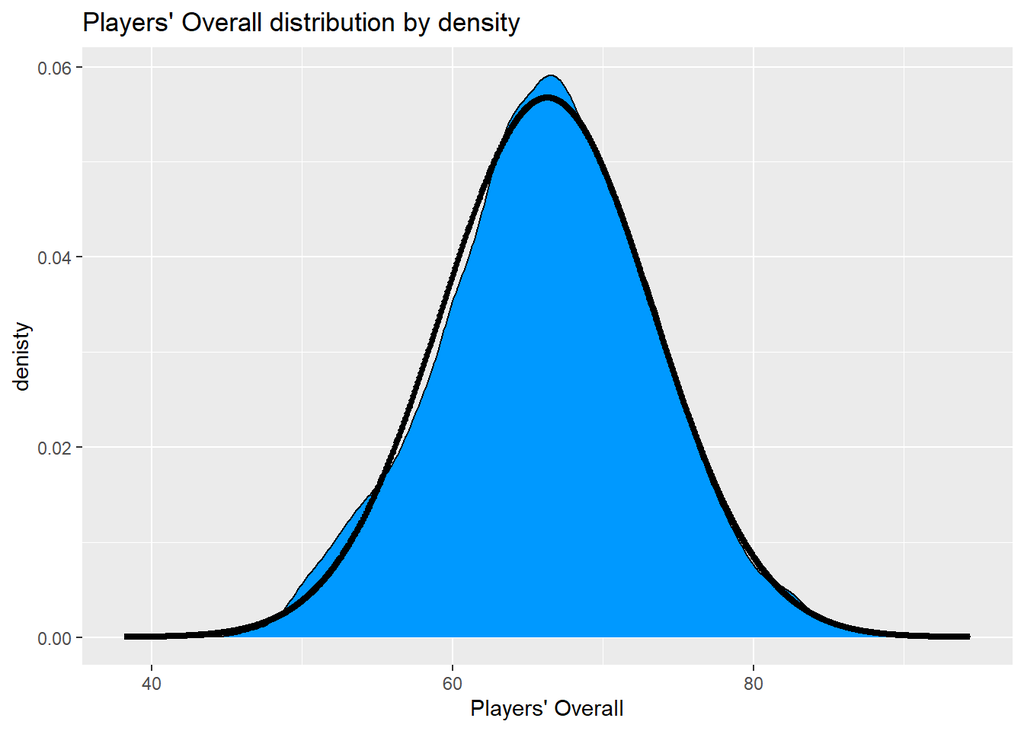

```r
# two moments
mu <- round(mean(fifa_players$Overall),3)
sigma <- round(sd(fifa_players$Overall),3)

# Plot density
norm_dist <- data.frame(x=seq(-4,4,len=1655)*sigma+mu) %>% mutate(density=dnorm(x,mu,sigma))

#
ggplot(data = fifa_players,aes(x=Overall))+
geom_density(fill="#0099FF")+ # density
xlab("Players' Overall")+
ylab("denisty")+
  labs(title="Players' Overall distribution by density")+
geom_line(aes(x, density),  data = norm_dist, lwd=1.5) # density of normal distrubition
```

```r
#skewness
print(round(skewness(fifa_players$Overall), 3))
```

```
## [1] 0.008
```

```r
#kurtosis
print(kurtosis(fifa_players$Overall))
```

```
## [1] -0.02102
```

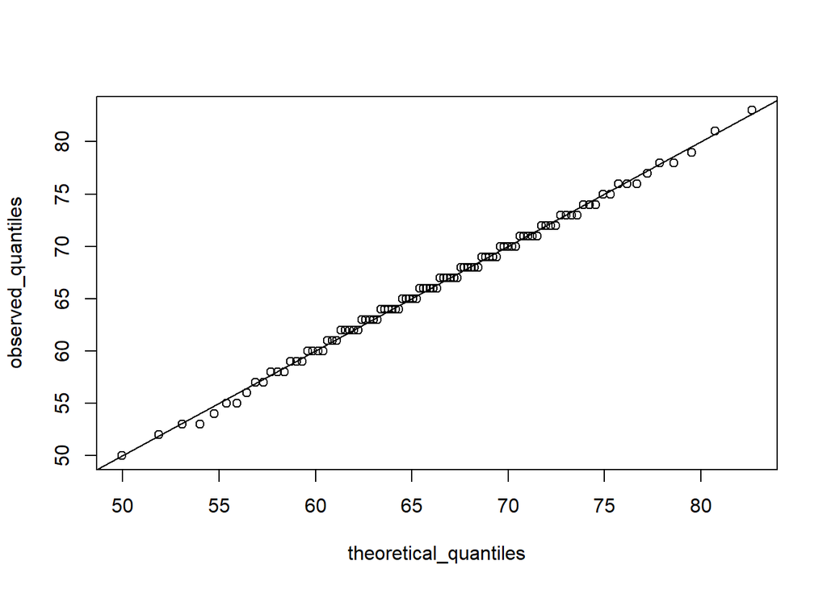

```r
# check  if distrubition is normal by QQ plot
x<-fifa_players$Overall
p <- seq(0.01, 0.99, 0.01)
observed_quantiles <- quantile(x, p)
theoretical_quantiles <- qnorm( p, mean = mean(x), sd = sd(x))
plot(theoretical_quantiles, observed_quantiles)
abline(0,1)
```

conclusion: the data are fairly symmetrical, although The skewness is positive (shows a very small right tail). also its time the data is fairly with no tails The kurtosis is negative, so we have short tails.

As we see the plots’ density is very similar. To make sure, I also ran a QQ- plot, that shows us that the points overlap the line. Therefore, the distribution is described well by a Normal distribution. _______________________________________________________________________________________

b) a plot comparing the multiple `overall` ability distributions of players according to the `continent` of the players:

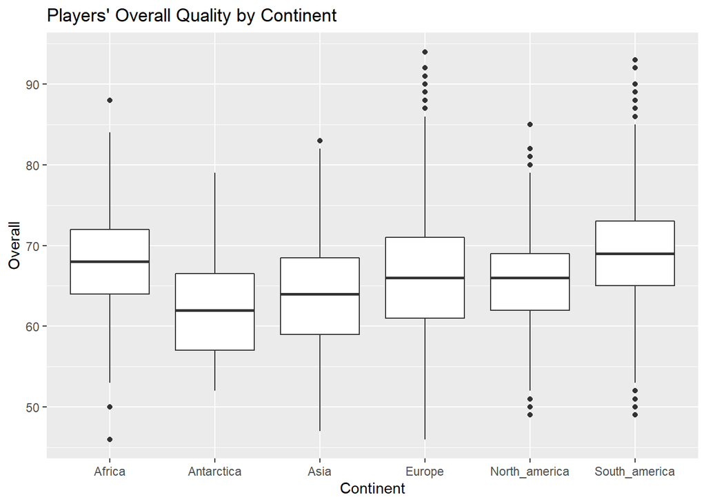

```r
ggplot(data = fifa_players,aes(x=Continent,y = Overall))+geom_boxplot()+
xlab("Continent")+ylab("Overall")+labs(title="Players' Overall Quality by Continent")
```

c) a plot showing the *density* of players’ `value` distribution:

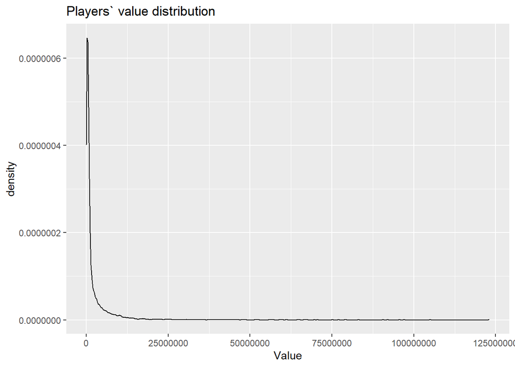

```r
# The density of players' value distribution.
ggplot(data = fifa_players,aes(x=Value))+
  geom_density()+
  labs(title="Players` value distribution")
```

a plot showing the *density* distribution of the *log* of players’ `value`:

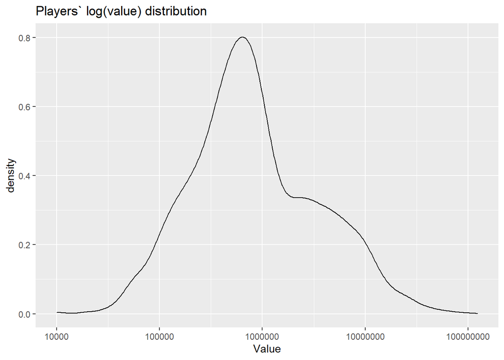

```r
# The density of log players' value distribution.

ggplot(data = fifa_players,aes(x=Value))+
  scale_x_continuous(trans='log10')+
  geom_density()+
  labs(title="Players` log(value) distribution ")
```

**Conclusion**: The log(value)is the better visualization, because the data have a very skewed distribution and the small number of very large values that can mislead in analysis. Although the log transformed data are still skewed, the skewness is much less and the data much easier to analyze. One very high value makes it very difficult to see the structure in the rest of the data. After the transformation, the variability becomes more similar to a normal distribution.

d) tables of top-10 players with the highest `value` and the top-10 best players in terms of `overall` ability:

```r
#  table of the top-10 players with the highest value:
top_10_value<-fifa_players[,c(2,6,10)] %>% arrange(desc(fifa_players$Value)) %>% head(10)
print(top_10_value)
```

```
##                 Name Overall     Value
## 1             Neymar      92 123000000
## 2           L. Messi      93 105000000
## 3         L. SuÃ¡rez      92  97000000
## 4  Cristiano Ronaldo      94  95500000
## 5     R. Lewandowski      91  92000000
## 6          E. Hazard      90  90500000
## 7       K. De Bruyne      89  83000000
## 8          P. Dybala      88  79000000
## 9           T. Kroos      90  79000000
## 10       G. HiguaÃn      90  77000000
```

```r
#  table of the top-10 players with the highest overall:
top_10_overall<-fifa_players[,c(2,6,10)] %>% arrange(desc(fifa_players$Overall)) %>% head(10)
print(top_10_overall)
```

```
##                 Name Overall     Value
## 1  Cristiano Ronaldo      94  95500000
## 2           L. Messi      93 105000000
## 3             Neymar      92 123000000
## 4           M. Neuer      92  61000000
## 5         L. SuÃ¡rez      92  97000000
## 6     R. Lewandowski      91  92000000
## 7          E. Hazard      90  90500000
## 8             De Gea      90  64500000
## 9        G. HiguaÃn      90  77000000
## 10          T. Kroos      90  79000000
```

The tables show us mostly the same names, although not in the same positions.

e) a table of the 10 youngest and 10 oldest teams in terms of average players `age`:

```r
top_10_youngest_team<-fifa_players %>% group_by(Club) %>% summarise(averge_age=mean(Age))
# table of the oldest
highest<-top_n(top_10_youngest_team,10,averge_age)
print(highest)
```

```
## # A tibble: 10 x 2
##    Club                                averge_age
##    <chr>                                    <dbl>
##  1 Adelaide United                           30.4
##  2 AssociaÃ§Ã£o Chapecoense de Futebol       30.6
##  3 Brisbane Roar                             31
##  4 Clube AtlÃ©tico Paranaense               30
##  5 FC Seoul                                  30.8
##  6 GrÃªmio Foot-Ball Porto Alegrense         30
##  7 Jeonbuk Hyundai Motors                    30.3
##  8 Newcastle Jets                            31
##  9 Sydney FC                                 30
## 10 Western Sydney Wanderers                  30.8
```

```r
# table of the youngest
lowest<-top_n(top_10_youngest_team,-10,averge_age)
print(lowest)
```

```
## # A tibble: 10 x 2
##    Club               averge_age
##    <chr>                   <dbl>
##  1 Ajax                     22.1
##  2 Barnsley                 22.1
##  3 Crewe Alexandra          21.9
##  4 FC Barcelona B           20.4
##  5 FC NordsjÃ¦lland         22
##  6 KRC Genk                 22.1
##  7 LOSC Lille               21.6
##  8 PSV                      21.9
##  9 Sevilla AtlÃ©tico       19.8
## 10 Werder Bremen II         21.5
```

## Q2. Scouting Report (30 pt)

You are in charge of the scouting division. The goal of this division is to follow players’ `potential` and `overall` ability, and identify undervalued players - that is, players whose current value is lower compared to what would be expected based on their predicted future ability.

1. Plot the *average* `potential` ability by `age` of all players, for players 35 years old or younger
2. Plot the *average difference* between a player’s `overall` ability to `potential` ability as a function of `age`, up to age 35. At what ages should we expect to find players for future development based on this graph?
3. We are seeking young ($age \leq 21$) players with high `potential` ($>70$). Show a scatter plot of these players comparing their `potential` ability (x-axis) and current `value` (y-axis).  
   Find the 10 most-undervalued players, i.e. having the lowest `value` compared to their predicted value by `potential` using a simple linear regression model.  
   Calculate for each of them what is a fair `value` matching their `potential` that you be willing to pay in order to by them to your club and show these 10 players with their name, `age`, `overall` ability, `potential`, actual `value` and fair `value` it a table.
4. Your boss wants to fly abroad to recruit promising players. Use the `rworldmap` package to display the world map and color each country based on the *median* `potential` of players from this nationality.
5. Repeat the above analysis but this time display a world map where each country is colored by the *median ratio* of `potential` to `value` of players. Find an under-valued country you’d recommend to travel to (i.e. a country with cheap players compared to their `potential` average quality).

## Answer 2

a) I have plotted the *average* `potential` ability by `age` of all players:

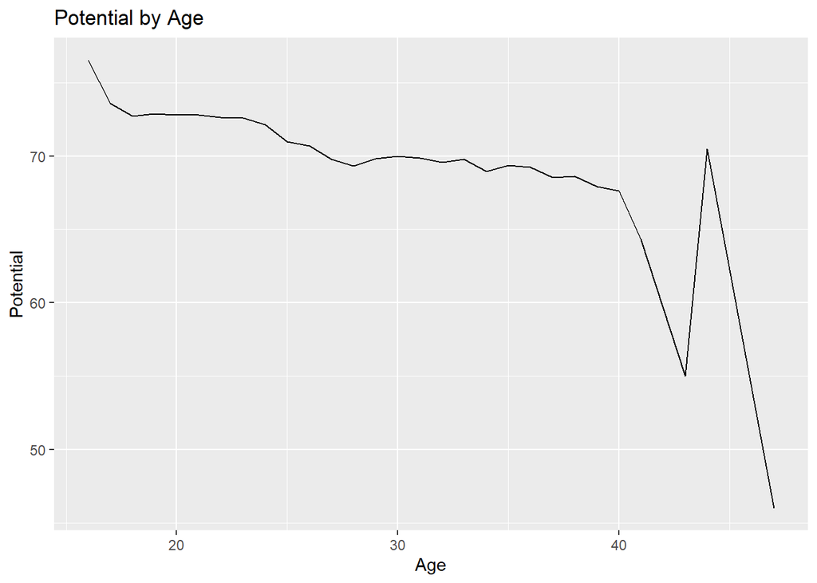

```r
potential_mean <- aggregate(fifa_players$Potential, by = list(fifa_players$Age),FUN = mean)

ggplot(data =potential_mean ,aes(x=Group.1,y=x))+
   xlab("Age")+
  ylab("Potential")+
  labs(title="Potential by Age") +
  geom_line()
```

now,I have plotted the *average* `potential` ability by `age` for players 35 years old or younger:

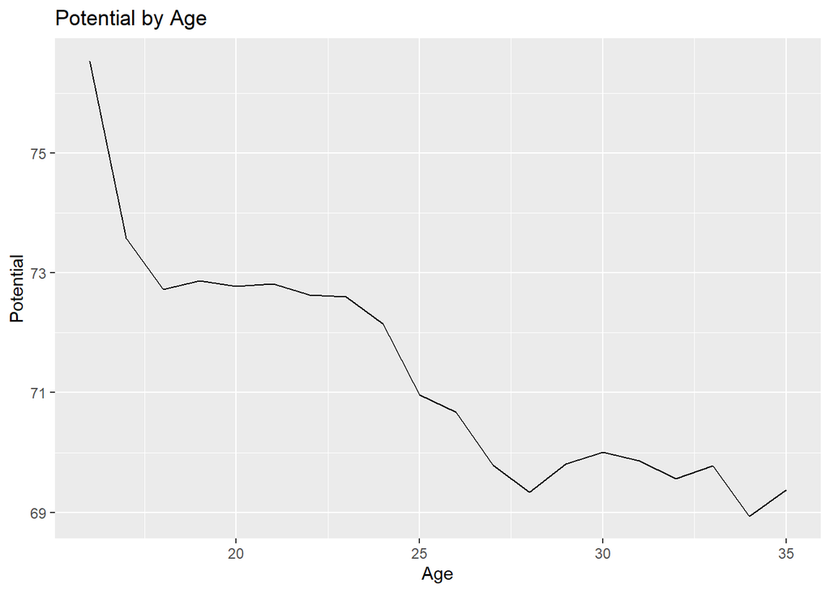

```r
potential_mean_young<-potential_mean[potential_mean$Group.1<=35,]
ggplot(data =potential_mean_young ,aes(x=Group.1,y=x))+
   xlab("Age")+
  ylab("Potential")+
  labs(title="Potential by Age") +
  geom_line()
```

b) A plot of the *average* difference between a player’s `overall` ability to `potential` ability as a function of `age`:

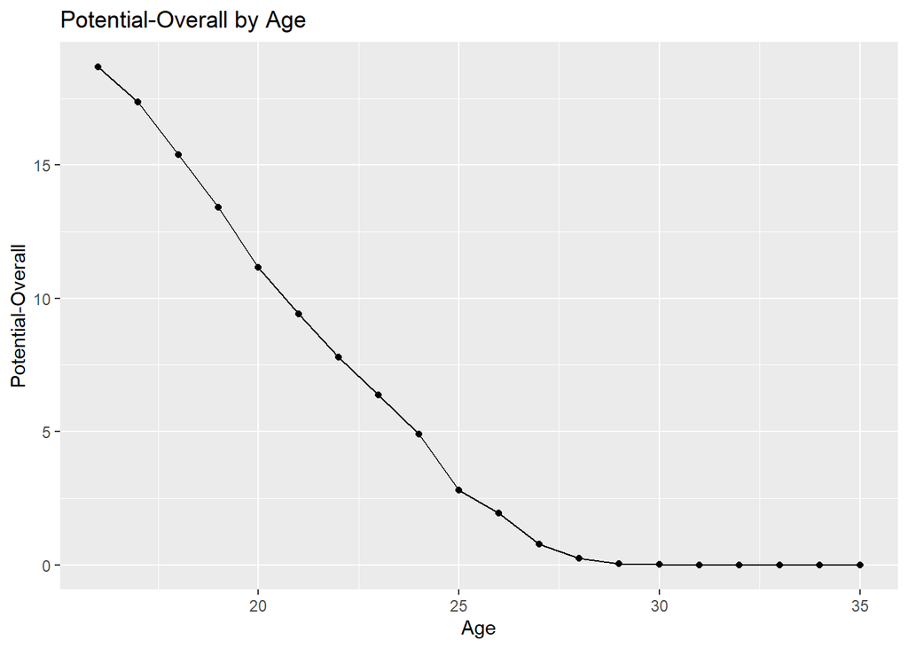

```r
fifa$diffrence <- fifa$Potential-fifa$Overall
mean_diffrence<- aggregate(fifa$diffrence, by = list(fifa$Age),FUN = mean)
mean_diffrence_youngs<-mean_diffrence[mean_diffrence$Group.1<=35,]


ggplot(mean_diffrence_youngs,aes(x=Group.1,y=x))+
  geom_line()+
  geom_point()+
   xlab("Age")+
  ylab("Potential-Overall")+
  labs(title="Potential-Overall by Age")
```

*Conclusion*:We can expect to find players for future development up to the age of 25.

c) a scatter plot of these players comparing their `potential` ability (x-axis) and current `value` (y-axis) in order to find the proper value for the ten most undervalued players.

```r
potential_value <- fifa_players[fifa_players$Overall>70 & fifa_players$Age<=21,]

lm_potential <- lm(Value ~ Potential, data=potential_value)
potential_value$resid <-resid(lm_potential) # The residuals show us the lowest value compared to their predicted value by potential.

#the most 10  undervalued players:
print(potential_value %>% arrange(resid) %>% select(Name, Age, Potential, Value, resid) %>% head(10))
```

```
##                Name Age Potential   Value     resid
## 1      W. FarÃÃ±ez  19        87       0 -14838179
## 2          E. Barco  18        90 6500000 -13273274
## 3      L. MartÃnez  19        88 6500000  -9983210
## 4           AleÃ±Ã   19        87 5000000  -9838179
## 5     B. DrÄ…gowski  19        86 4200000  -8993147
## 6        K. Havertz  18        88 8000000  -8483210
## 7           Vitinho  19        86 5000000  -8193147
## 8  Christian Rivera  19        85 4600000  -6948115
## 9      Jorge SÃ¡enz  20        85 4700000  -6848115
## 10    K. Amian Adou  19        86 6500000  -6693147
```

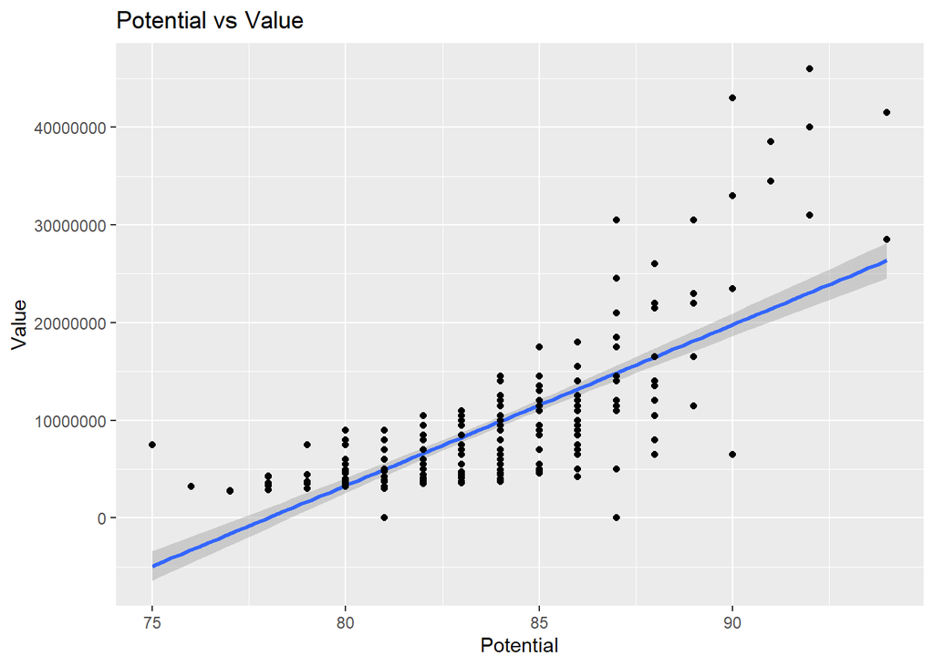

```r
potential_value$fair_value<-lm_potential$fitted.values # The predicted value shows us the fair value that matches their potential.


ggplot(potential_value,aes(x=Potential,y=Value))+xlab("Potential")+ylab("Value")+
  labs(title="Potential vs Value")+
  geom_smooth(method='lm', formula= y~x) +
  geom_point()
```

```r
#the most 10  undervalued players with their corrected value:"
print(potential_value %>% arrange(resid) %>% select(Name, Age,Overall, Potential, Value, fair_value) %>% head(10))
```

```
##                Name Age Overall Potential   Value fair_value
## 1      W. FarÃÃ±ez  19      73        87       0   14838179
## 2          E. Barco  18      72        90 6500000   19773274
## 3      L. MartÃnez  19      72        88 6500000   16483210
## 4           AleÃ±Ã   19      71        87 5000000   14838179
## 5     B. DrÄ…gowski  19      71        86 4200000   13193147
## 6        K. Havertz  18      73        88 8000000   16483210
## 7           Vitinho  19      71        86 5000000   13193147
## 8  Christian Rivera  19      71        85 4600000   11548115
## 9      Jorge SÃ¡enz  20      71        85 4700000   11548115
## 10    K. Amian Adou  19      73        86 6500000   13193147
```

d) the world map and color each country based on the median `potential` of players from this nationality:

```r
median_potential<- fifa %>% group_by(Nationality) %>% summarise(med=median(Potential))



map_potential <- joinCountryData2Map(dF = median_potential, joinCode = "NAME", nameJoinColumn = "Nationality",verbose=F)
```

```
## 133 codes from your data successfully matched countries in the map
## 4 codes from your data failed to match with a country code in the map
## 110 codes from the map weren't represented in your data
```

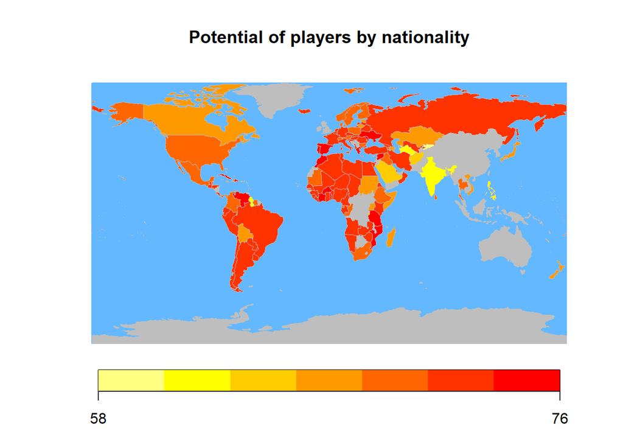

```r
mapCountryData(mapToPlot = map_potential, nameColumnToPlot = "med",catMethod = "fixedWidth",oceanCol = "steelblue1", missingCountryCol = "grey",mapTitle = "Potential of players by nationality",aspect = "variable")
```

e) A world map where each country is colored by the median ratio of `potential` to `value` of players

```r
med_potential_value<- fifa %>% group_by(Nationality) %>% summarise(med=median(Potential/Value))
med_potential_value<-med_potential_value[med_potential_value$med!=Inf,] # Remove inf values from table

map_potential_value<- joinCountryData2Map(dF = med_potential_value, joinCode = "NAME", nameJoinColumn = "Nationality",verbose=F)
```

```
## 131 codes from your data successfully matched countries in the map
## 4 codes from your data failed to match with a country code in the map
## 112 codes from the map weren't represented in your data
```

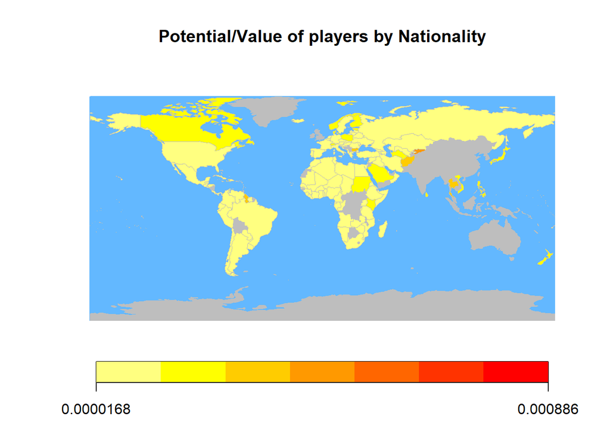

```r
mapCountryData(mapToPlot = map_potential_value, nameColumnToPlot = "med",catMethod = "fixedWidth",
               oceanCol = "steelblue1", missingCountryCol = "grey",
               mapTitle = "Potential/Value of players by Nationality")
```

```r
med_potential_value<-med_potential_value %>% arrange(desc(med))
under_represented_country <- head(med_potential_value,10)

#an under-valued country you’d recommend to travel to:
print(under_represented_country)
```

```
## # A tibble: 10 x 2
##    Nationality              med
##    <chr>                  <dbl>
##  1 San Marino          0.000886
##  2 Kyrgyzstan          0.000446
##  3 Republic of Ireland 0.000336
##  4 Afghanistan         0.000333
##  5 Guyana              0.000321
##  6 Thailand            0.000316
##  7 Bulgaria            0.000296
##  8 New Zealand         0.000263
##  9 Sudan               0.000257
## 10 Saudi Arabia        0.000238
```

## Q3. Correlations Analysis (30 pt)

In this question we find and display different skills and their correlations

1. We are interested in finding out which positions are similar in terms of players’ performance.  
   Extract the 26 non-goalkeeper positions (`CAM, CB, ..., ST`). Calculate the correlation between players’ ability in each pair of positions and show a heatmap correlation-plot of the correlations’ matrix. What three positions have the *least* average correlations with other positions?
2. Consider the following indicators of players performance: `overall` players’ performance, their `potential`, their salary (`wage`) and their market `value`. Show a correlation-plot of players’ *34* skill levels (`Acceleration`, …, `Volleys`) vs. these four indicators. Find the *10* skills with the highest *average* correlation with the four inidcators and list them in a table.
3. Build a team of *11 different* players with the following rules:
- For each of the *26* non-goalkeaper positions (*26* from above plus goalkeaper, `GK`), find the player with the best performance at this position.
- Find the goal keaper (`Preffered.Positions` is `GK`) with the best `overall` performance.
- From the players obtained above, find *11 distinct* players maximizing the average `overall` performance of the team, with the constraint that there must be a goalkeaper (preferred position `GK`).
- List the players in a table including their `overall` performance and the team average `overall` score.  
  Next, peak six *different* players of your choice from your team, one of which is the goalkeaper. Using the function `radarchart::chartJSRadar`, graph their abilities (individually for all 6 players) in the top *10* skills according to 3.b in a [radar chart](https://en.wikipedia.org/wiki/Radar_chart) (also called ‘spider chart’) graph. See below an example for such a chart.
4. We are interested in determining how the player’s abilities in different `positions` changes with age. Repeat the analysis of question 2.a., but this time show the *26* different `positions` (except goal-keaper). Abilities in which `positions` peak at youngest/oldest ages?
5. Your boss suggests that some players may be currently under-payed compared to their performance, and that we can acquire them by offering them a higher salary (`wage`).  
   Fit a multiple regression model predicting player’s `overall` performance based on their `wage` and `age`.  
   Find the $10$ players with the highest difference between their `overall` performance level and the regression model prediction, and list them in a table.

## Answer 3

a)

Extract the 26 non-goalkeeper `positions` and Calculate the correlation between players’ ability in each pair of positions by heatmap correlation-plot:

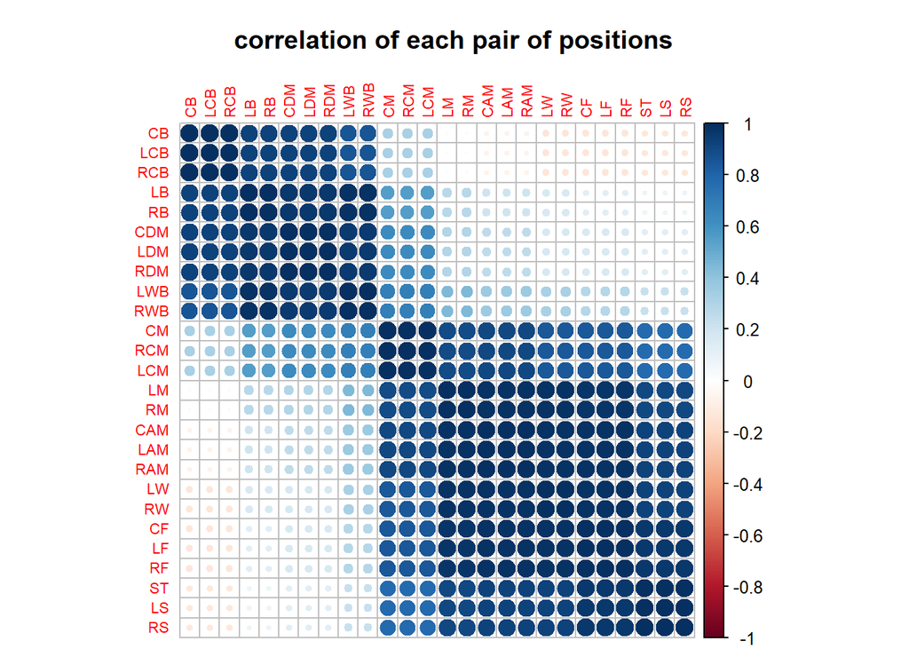

```r
#corrplot for positions
table_pos<-fifa_players_positions[(fifa_players_positions$Preferred.Positions!="GK "),]
table_pos<-table_pos[,2:27]
Cor_positions<-cor(table_pos,table_pos)

corrplot(Cor_positions, order="AOE", tl.cex = 0.7,
         mar=c(0,0,3,0), title="correlation of each pair of positions")
```

The three `positions` have the least *average* correlations with other `positions`:

```r
averge_cor_pos<-rowMeans(Cor_positions)
averge_cor_pos<-sort(averge_cor_pos)
print(averge_cor_pos[c(1,2,3)])
```

```
##     CB    LCB    RCB
## 0.3459 0.3459 0.3459
```

According to the heatmap plot above, the positions with the least average correlation with others (the empty squares above with the least coloration) are: CB, LCB, and RCB.

b) correlation-plot of players’ 34 skill levels vs. these four indicators :`wage`, `value`, `potential` and `overall`:

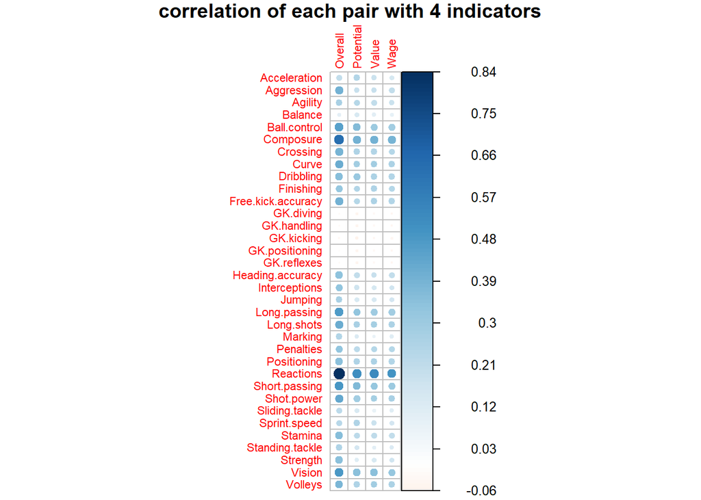

```r
cor_skill_indicators<-cor(fifa_players_attribures[,-c(1,36)],fifa_players_indicators[,-c(1)])
cor_skill_indicators<-round(cor_skill_indicators,3)


corrplot(cor_skill_indicators, method = "circle",
         is.corr = FALSE, tl.cex = 0.7,win.asp = .7, cl.ratio = 2, cl.align = "r",
       title="correlation of each pair with 4 indicators",  mar=c(0,0,1,0))
```

```r
# a table of 10 skills with the highest average correlation with the four indicators
averge_cor<-rowMeans(cor_skill_indicators)
averge_cor<-sort(averge_cor, decreasing = T)
print(top_10_skills<-as.data.frame(averge_cor[1:10]))
```

```
##               averge_cor[1:10]
## Reactions               0.5995
## Composure               0.4577
## Short.passing           0.3748
## Vision                  0.3745
## Ball.control            0.3558
## Long.passing            0.3503
## Shot.power              0.3175
## Curve                   0.3142
## Long.shots              0.3090
## Dribbling               0.2993
```

c)

*(1)* the best 26 non-goalkeeper players in terms of performance at this `position`:

```r
non_GK<-fifa_players_positions[,2:27] # Remove GK positions
max_pos<-non_GK %>% summarise_all(max)
BEST_player<-max_pos[-c(1,2),] # Build empty data frame

# find beat player in each postion.
for (i in 1:length(max_pos)){
     temp<-fifa$Name[which(non_GK[,i] %in% max_pos[1,i])]
     BEST_player[1:length(temp),i]<-temp

}
```

*(2)* a goal keaper with the best `overall` performance:

```r
GK<-fifa_players_positions[(fifa_players_positions$Preferred.Positions=="GK "),]
index_best_GK<-GK %>% summarise(MAX=which.max(Overall))
index_best_GK<-index_best_GK[1,1] # change data frame to numeric
best_GK<-fifa$Name[fifa$ID==GK$ID[index_best_GK]]
```

*(3)* From the players obtained above, I found 11 distinct players maximizing the average `overall` performance of the team, with the constraint that there must be a goalkeaper (preferred position GK):

```r
#same as a but this time we are using ID in order to prevent confusion over players with the same name.
non_GK<-fifa_players_positions[,2:27]
max_pos<-non_GK %>% summarise_all(max)
best_players<-max_pos[-c(1,2),]
for (i in 1:length(max_pos)){
    temp2<-fifa$ID[which(non_GK[,i] %in% max_pos[1,i])]
     best_players[1:length(temp2),i]<-temp2

}

# arrange data to find the best player in one column
colnames(best_players)<-colnames(fifa)[2]
t<-as.vector(t(best_players))
t<-unique(t)
t<-na.omit(t)
t<-as.data.frame(t)
colnames(t)<-"ID"


team_GK<-rbind(t,GK$ID[index_best_GK]) #  Add the best goalkeeper to the table.

team<-left_join(team_GK,fifa_players[,c(1,2,6)],by = "ID")  # get name and overall by  match ID


top_team<-team[-which.min(team$Overall),] # delete one player that have lowest overall value

averge_team<-round(mean(top_team$Overall,3))
```

```r
team_players_overall_mean<-top_team[,c(2,3)] %>% cbind(averge_team)
print(team_players_overall_mean)
```

```
##                 Name Overall averge_team
## 1           L. Messi      93          87
## 2       Sergio Ramos      90          87
## 3           A. Vidal      87          87
## 4           T. Kroos      90          87
## 6  Cristiano Ronaldo      94          87
## 7           D. Alaba      86          87
## 8        Alex Sandro      86          87
## 9      R. Nainggolan      86          87
## 10           Marcelo      87          87
## 11        Jordi Alba      85          87
## 12          M. Neuer      92          87
```

Next, I peak six different players of your choice from your team, one of which is the goalkeeper. I graph their abilities by the *top 10 skills* according to 3.b

```r
six_players<-data.frame(Name=top_team$Name[c(1:5,11)])
six_players_info<-left_join(six_players,fifa)
```

```r
radar<-six_players_info %>% select(Name,rownames(top_10_skills))

radar <- gather(radar, key=skills, value=val, -Name) %>%
  spread(key=Name, value=val)

chartJSRadar(radar)
```

[interactive chart not shown]

```r
no_GK<-fifa_players_positions[(fifa_players_positions$Preferred.Positions!="GK ")   ,]
temp_no_Gk<-fifa_players[,c(1,3)]
no_GK_age<-left_join(no_GK,temp_no_Gk, by="ID")
no_GK_age<-no_GK_age[,c(2:26,31)] # get positions and age

melt_table<-melt(no_GK_age,id.vars = "Age")

mean_pos<-melt_table %>% group_by(Age,variable) %>% summarise(mean_value=mean(value)) # get mean of each same Age and position.
```

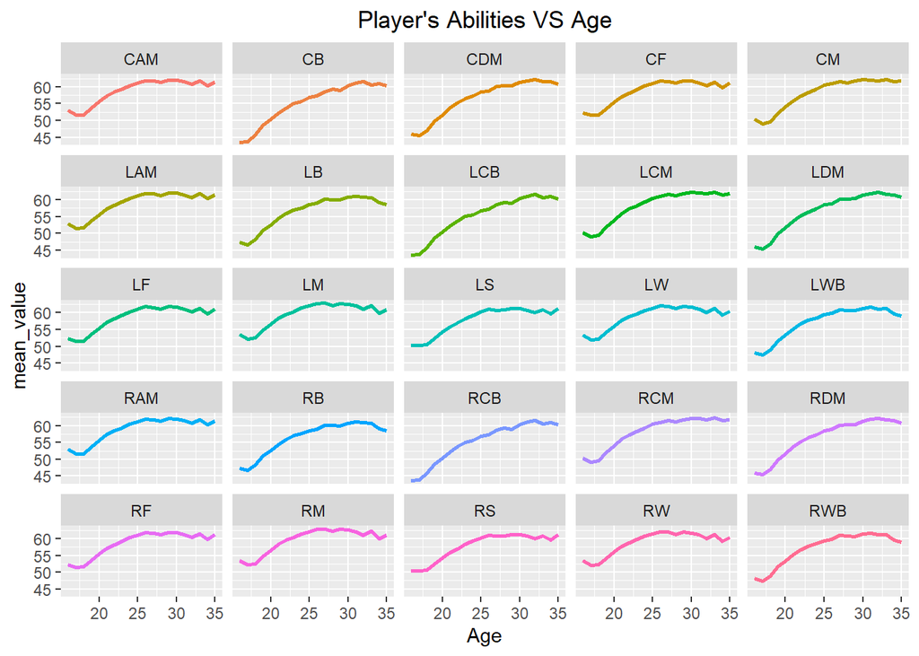

```r
mean_pos<-mean_pos[mean_pos$Age<=35,] # conditions as q2

ggplot(data=mean_pos, aes(x=Age, y=mean_value, color=variable)) +
  geom_line(size=1)+
  ggtitle("Player's Abilities VS Age") +
  theme(plot.title = element_text(hjust = 0.5))+
  facet_wrap(~variable  )+
  theme(legend.position="none")
```

e) a multiple regression model predicting player’s `overall` performance based on their `wage` and `age`:

```r
lm_overall <- lm(Overall ~ Age+Wage ,data=fifa_players)
fifa_players$fitted <-lm_overall$fitted.values
fifa_players$resid <- round(resid(lm_overall), 3)
```

```r
print(fifa_players %>% arrange(resid) %>% select(Name,Overall,fitted,resid) %>% head(10))
```

```
##                 Name Overall fitted  resid
## 1  Cristiano Ronaldo      94 159.14 -65.14
## 2           L. Messi      93 157.99 -64.99
## 3         L. SuÃ¡rez      92 149.15 -57.15
## 4            G. Bale      89 124.93 -35.93
## 5         L. ModriÄ‡      89 122.41 -33.41
## 6     R. Lewandowski      91 123.10 -32.10
## 7      B. Richardson      46  77.17 -31.17
## 8           T. Kroos      90 120.11 -30.11
## 9         S. AgÃ¼ero      89 118.85 -29.85
## 10        K. Benzema      86 114.03 -28.03
```